# Assignment 8

Eric Zhou

2023-01-03

# **Apprentice**

## Problem 1

#### **Part a**:

```r
rolls <- c()
for (j in 1:1000) {
  rolls[j] = sample(1:4, 1) + sample(1:8, 1)
}
head(rolls)
```

```
## [1] 11  3  6 10  9  3
```

```r
length(rolls)
```

```
## [1] 1000
```

#### **Part b**:

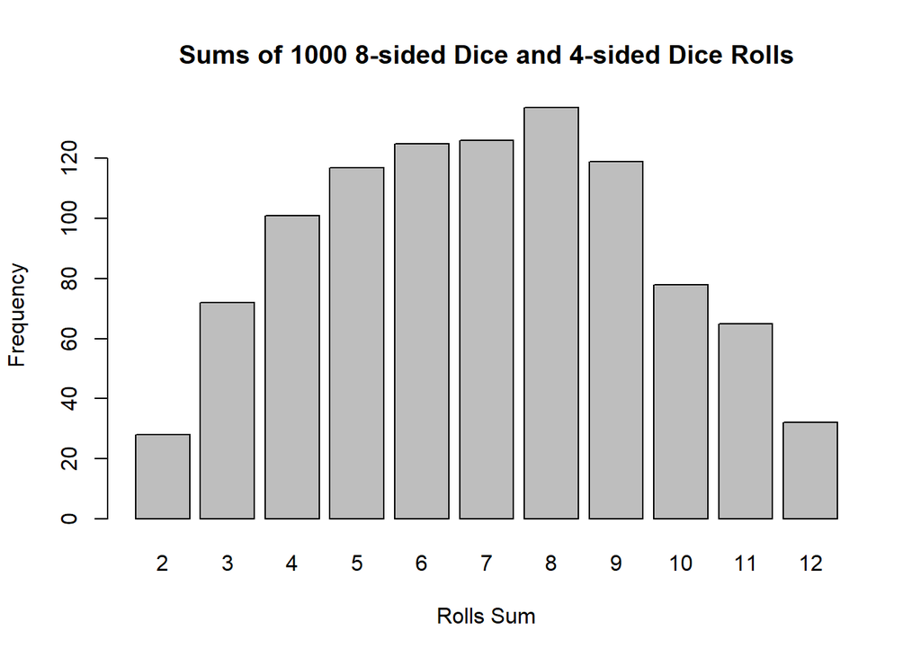

```r
barplot(table(rolls), ylab="Frequency", xlab="Rolls Sum", main="Sums of 1000 8-sided Dice and 4-sided Dice Rolls")
```

#### **Part c**:

```r
roll_pos <- 2:12
sim_prob <- c()
for (j in roll_pos){
  sim_prob[j - 1] = sum(rolls == j)/length(rolls)
}
true_prob <- c(1/32, 2/32, 3/32, 4/32, 4/32, 4/32, 4/32, 4/32, 3/32, 2/32, 1/32)
df <- data.frame(roll_pos, sim_prob, true_prob)
colnames(df) <- c("Roll Sum", "Simulated Probability", "True Probability")
df
```

```
##    Roll Sum Simulated Probability True Probability
## 1         2                 0.028          0.03125
## 2         3                 0.072          0.06250
## 3         4                 0.101          0.09375
## 4         5                 0.117          0.12500
## 5         6                 0.125          0.12500
## 6         7                 0.126          0.12500
## 7         8                 0.137          0.12500
## 8         9                 0.119          0.12500
## 9        10                 0.078          0.09375
## 10       11                 0.065          0.06250
## 11       12                 0.032          0.03125
```

## Problem 2

```r
skittle_col <- c(rep("P", 7), rep("R", 6), rep("Y", 5), rep("O", 4), rep("G", 3))
skittle_bowl <- c(7, 6, 5, 4, 3)
skittle_col
```

```
##  [1] "P" "P" "P" "P" "P" "P" "P" "R" "R" "R" "R" "R" "R" "Y" "Y" "Y" "Y" "Y" "O"
## [20] "O" "O" "O" "G" "G" "G"
```

```r
matches <- 0
for (j in 1:10000){
  curr <- sort(sample(skittle_col, 4, replace=FALSE))
  if (identical(curr, c("G", "P", "P", "R"))) {
    matches <- matches + 1
  }
}
matches/10000
```

```
## [1] 0.0302
```

#### **Part b**: If I did it correctly, it should be around 2.99%

```r
7/25*6/24*6/23*3/22*4*3*2/2
```

```
## [1] 0.02988142
```

```r
matches <- 0
for (j in 1:10000){
  curr <- sort(sample(skittle_col, 4, replace=TRUE))
  if ((sum(curr == "Y") >= 3) || (sum(curr == "O") >= 3)) {
    matches <- matches + 1
  }
}
matches/10000
```

```
## [1] 0.0406
```

# **Master**

```r
cards <- c(rep(2:10, 4*2), rep(10, 3*4*2), rep(11, 4*2), -1, -1)
matches <- 0
for (j in 1:10000){
  curr <- sort(sample(cards, 2, replace=FALSE))
  if (sum(curr == -1) == 2) { # both are jokers
    matches <- matches + 1
  } else if (sum(curr == -1) == 1) { # 1 joker
    if ((10 %in% curr) || (11 %in% curr)) {
      matches <- matches + 1
    }
  } else if (sum(curr) == 21) { # no jokers
      matches <- matches + 1
  }
}
matches/10000
```

```
## [1] 0.06
```

# **Wizard**

## Problem 4

#### **Part a**:

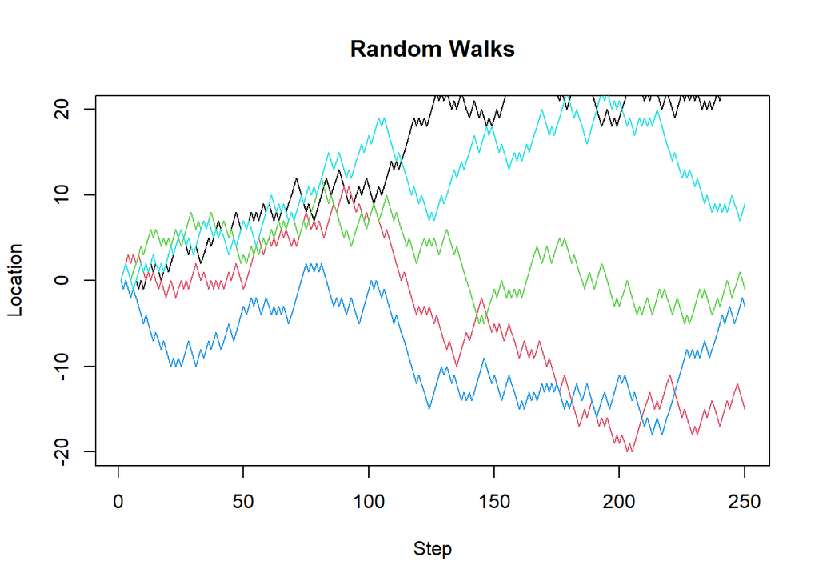

```r
options = c(-1, 1)
color = 1
plot_paths = sort(sample(1:1000, 5, replace=FALSE))
ends = c()
for (j in 1:1000){
  path = c(0)
  for (k in 2:250){
    path[k] = path[k - 1] + sample(options, 1)
  }
  if (j %in% plot_paths) {
    if (j == plot_paths[1]) {
      plot(x=1:250, y=path, type="l", col=color, ylim=c(-20, 20), xlab="Step", ylab="Location", main="Random Walks")
      color <- color + 1
    } else {
      lines(x=1:250, y=path, type="l", col=color)
      color <- color + 1
    }
  }
  ends[j] <- path[250]
}
```

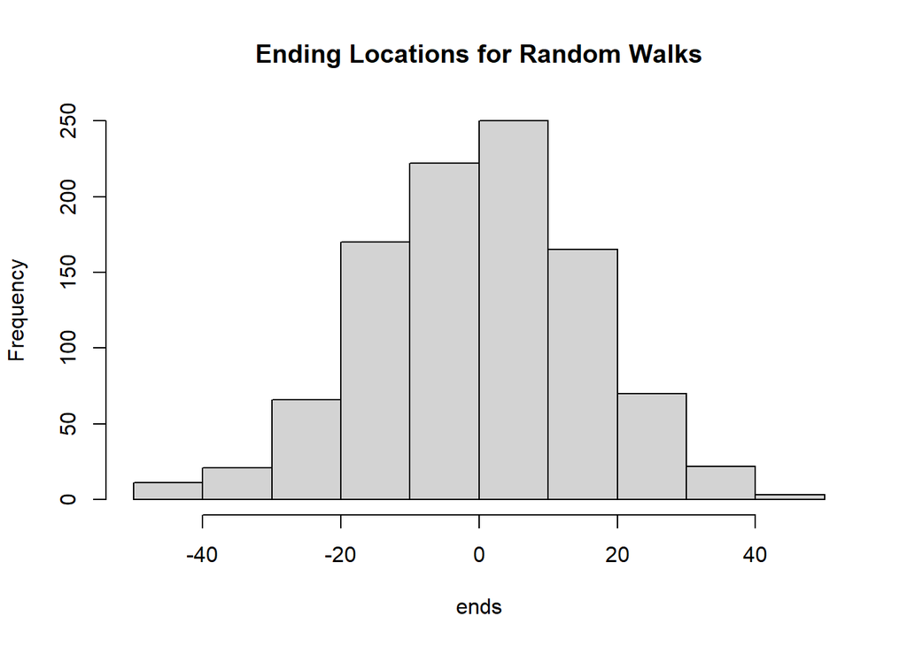

```r
hist(ends, main="Ending Locations for Random Walks")
```

```r
mean(ends)
```

```
## [1] -0.324
```

```r
sd(ends)
```

```
## [1] 15.77034
```

#### **Part c**: It fits pretty well.

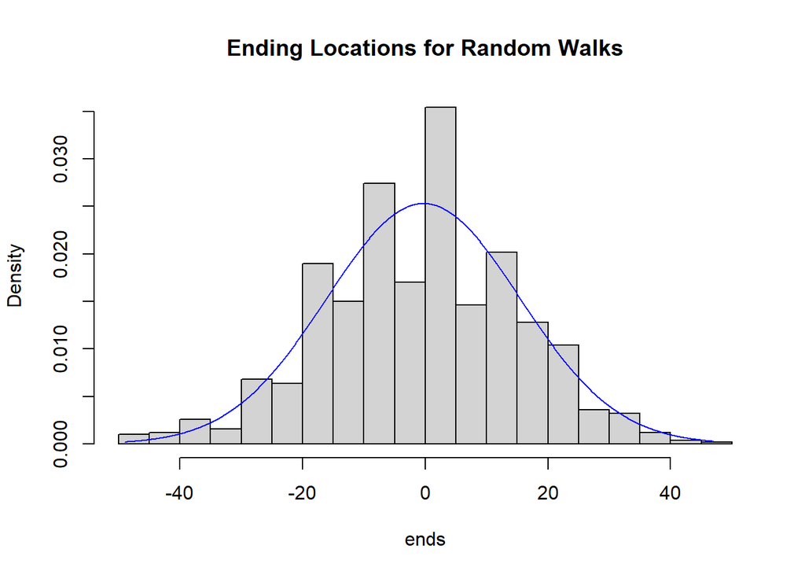

```r
hist(ends, main="Ending Locations for Random Walks", freq=FALSE, breaks = 20)
x <- seq(min(ends), max(ends), length=1000)
y <- dnorm(x, mean=mean(ends), sd=sd(ends))
lines(x, y, col="blue")
```

#### **Part d**: After more testing for ther resubmission, I have confirmed and disproved some of my previous statements (look at graphs below). Simulation number doesn’t sseem to really affect standard deviation which looks random but does decrease the absolute value of the mean, which makes sense as it should go to 0 with more simulations. When varying number of steps, the standard deviation clearly rose which makes sense since more steps are taken so there could be larger variance. Same thing happened when varying step sizes. As for the mean, I expected step count to lower the absolute value of mean since more steps should go to 0 but it looked pretty random. The step size seems to increase the absolute value of mean but the change is not very large and may be just due to the higher standard deviation allowing it to have more extreme outliers.

```r
sim_nums <- seq(25, 625, 25)
step_counts <- seq(25, 625, 25)
step_sizes <- 1:25
```

```r
step_count <- step_counts[5]
step_size <- step_sizes[1] * options
means <- c()
sds <- c()
for (sim_num in 1:length(sim_nums)) {
  ends = c()
  for (j in 1:sim_nums[sim_num]){
    path = c(0)
    for (k in 2:step_count){
      path[k] = path[k - 1] + sample(step_size, 1)
    }
    ends[j] <- path[step_count]
  }
  means[sim_num] <- mean(ends)
  sds[sim_num] <- sd(ends)
}
data.frame(sim_nums, means, sds)
```

```
##    sim_nums       means      sds
## 1        25 -0.96000000 11.28598
## 2        50  3.64000000 12.50430
## 3        75 -1.20000000 12.73853
## 4       100 -0.92000000 10.93755
## 5       125  0.99200000 11.28123
## 6       150 -0.20000000 11.19863
## 7       175 -0.53714286 10.95485
## 8       200  0.06000000 10.78788
## 9       225  0.88000000 10.37635
## 10      250  0.18400000 11.19444
## 11      275  1.11272727 11.27226
## 12      300  0.02000000 11.10664
## 13      325  0.35076923 11.49933
## 14      350 -0.76000000 11.53962
## 15      375 -0.06933333 11.48286
## 16      400 -0.36500000 11.32950
## 17      425  0.25411765 11.17576
## 18      450 -0.11555556 11.56775
## 19      475 -0.19789474 11.66926
## 20      500  0.42000000 11.35083
## 21      525  0.17904762 11.19664
## 22      550  0.46181818 11.29298
## 23      575 -0.10086957 10.82826
## 24      600 -0.25000000 11.04963
## 25      625  0.46720000 11.13607
```

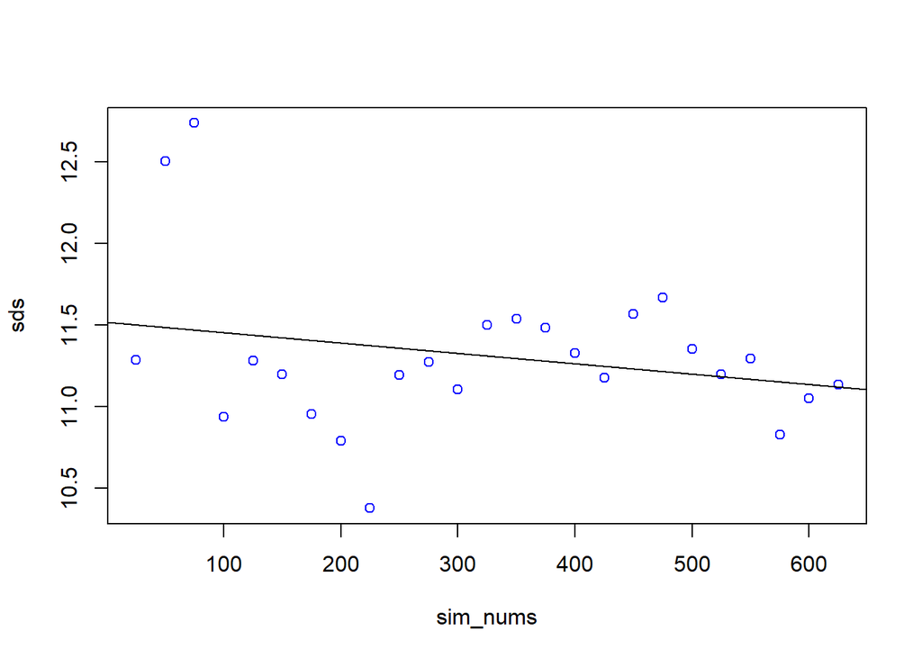

```r
plot(sim_nums, sds, col="blue")
abline(lm(sds~sim_nums))
```

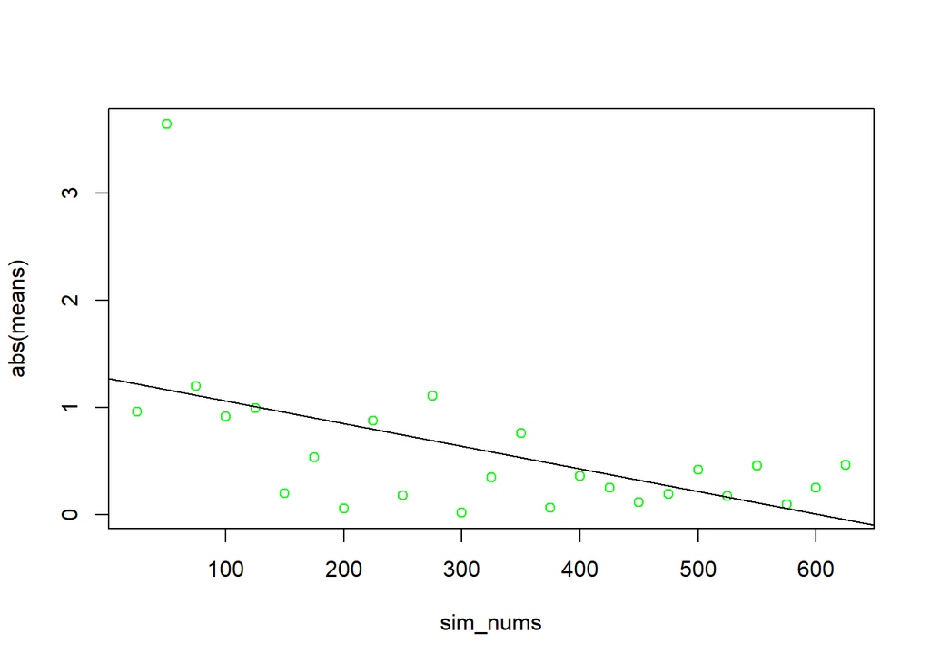

```r
plot(sim_nums, abs(means), col="green")
abline(lm(abs(means)~sim_nums))
```

```r
sim_num  <- sim_nums[10]
step_size <- step_sizes[1] * options
means <- c()
sds <- c()
for (step_count in 1:length(step_counts)) {
  ends = c()
  for (j in 1:sim_num){
    path = c(0)
    for (k in 2:step_counts[step_count]){
      path[k] = path[k - 1] + sample(step_size, 1)
    }
    ends[j] <- path[step_counts[step_count]]
  }
  means[step_count] <- mean(ends)
  sds[step_count] <- sd(ends)
}
data.frame(step_counts, means, sds)
```

```
##    step_counts  means       sds
## 1           25  0.408  5.396110
## 2           50 -0.040  6.564355
## 3           75 -0.520  8.748241
## 4          100  0.576  9.908630
## 5          125  0.392 11.935164
## 6          150  0.808 11.719408
## 7          175  0.488 12.776809
## 8          200 -0.960 13.283985
## 9          225 -1.432 14.327683
## 10         250 -0.456 16.191378
## 11         275 -0.664 17.049629
## 12         300  0.744 17.494419
## 13         325  0.000 17.825572
## 14         350 -1.424 18.920151
## 15         375 -1.712 19.483621
## 16         400 -2.000 19.939064
## 17         425 -0.512 20.604369
## 18         450 -0.232 20.690543
## 19         475 -1.192 21.314322
## 20         500 -2.936 22.703871
## 21         525 -0.776 22.007434
## 22         550 -0.488 23.630902
## 23         575  1.600 24.423308
## 24         600  1.312 24.761972
## 25         625  2.464 24.674766
```

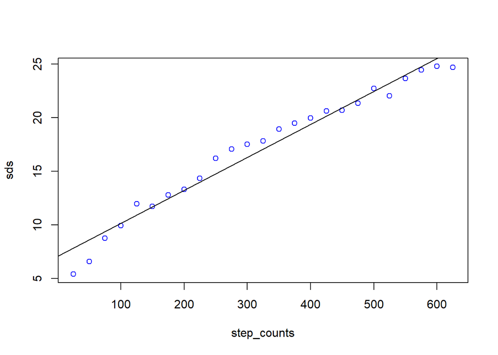

```r
plot(step_counts, sds, col="blue")
abline(lm(sds~step_counts))
```

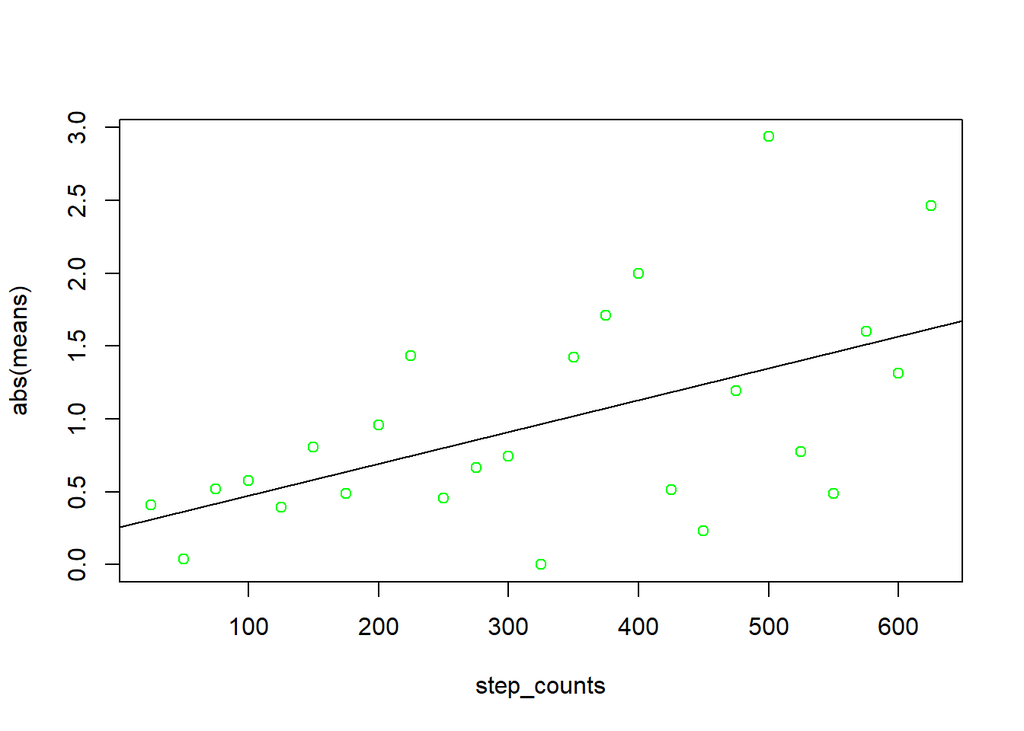

```r
plot(step_counts, abs(means), col="green")
abline(lm(abs(means)~step_counts))
```

```r
sim_num  <- sim_nums[10]
step_count <- step_counts[5]
means <- c()
sds <- c()
for (step_size in 1:length(step_sizes)) {
  ends = c()
  for (j in 1:sim_num){
    path = c(0)
    for (k in 2:step_count){
      path[k] = path[k - 1] + sample(step_sizes[step_size] * options, 1)
    }
    ends[j] <- path[step_count]
  }
  means[step_size] <- mean(ends)
  sds[step_size] <- sd(ends)
}
data.frame(step_counts, means, sds)
```

```
##    step_counts   means       sds
## 1           25  -0.264  11.83056
## 2           50  -1.952  23.31342
## 3           75  -0.816  35.72055
## 4          100   0.608  41.71906
## 5          125  -7.360  55.38683
## 6          150  -0.480  70.70154
## 7          175  -5.656  76.76424
## 8          200  -2.048  91.31207
## 9          225   2.232  88.19016
## 10         250  -2.000 107.69957
## 11         275 -10.560 123.37154
## 12         300   0.576 126.48369
## 13         325  -3.848 148.78062
## 14         350   6.048 156.67642
## 15         375 -19.200 157.34545
## 16         400   9.600 186.59597
## 17         425 -15.504 187.81460
## 18         450   1.584 189.07508
## 19         475   3.192 201.69961
## 20         500 -17.760 204.61685
## 21         525  -9.408 228.49007
## 22         550 -17.072 216.44355
## 23         575  34.040 250.43169
## 24         600  -1.728 250.85202
## 25         625 -31.400 269.99189
```

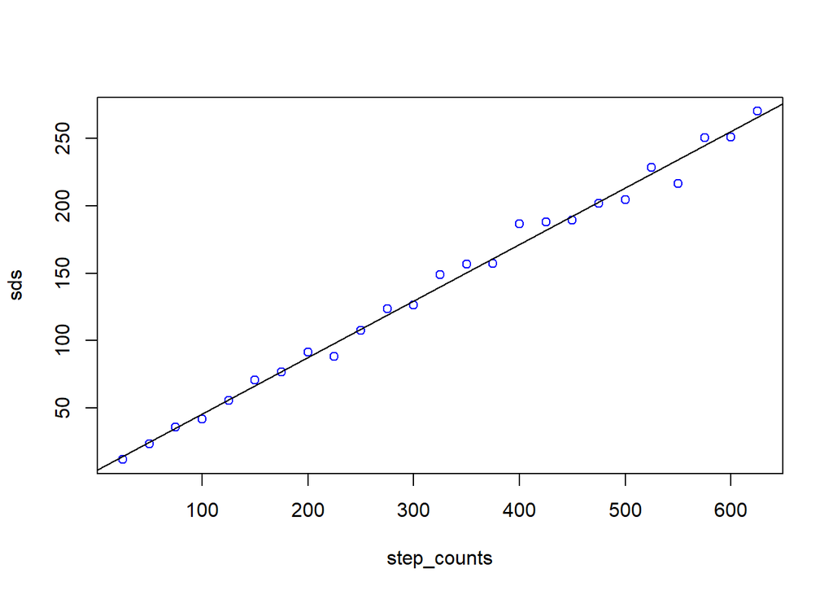

```r
plot(step_counts, sds, col="blue")
abline(lm(sds~step_counts))
```

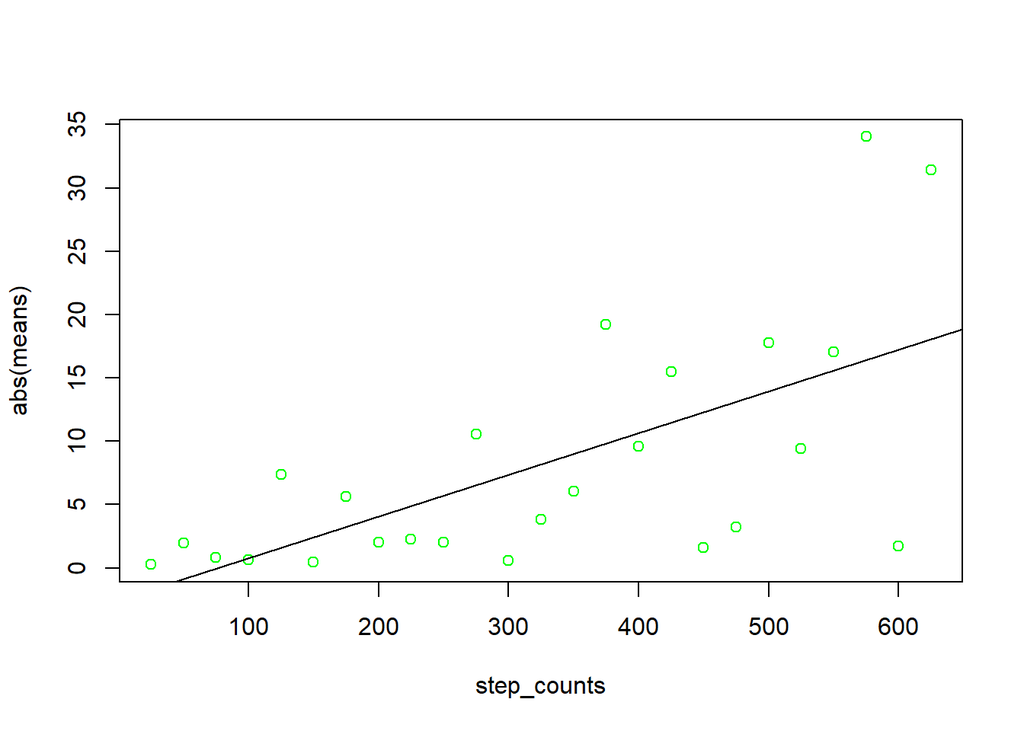

```r
plot(step_counts, abs(means), col="green")
abline(lm(abs(means)~step_counts))
```

#### **Part e**: As one would expect, the mean shifts while standard deviation is about the same as before. The mean is approximately the velocity multiplied by the step count since the velocity is the average move per step and you take step_count amount of steps so you would multiply. Standard deviation would be impacted if the range between the step choices were larger such as by scaling them.

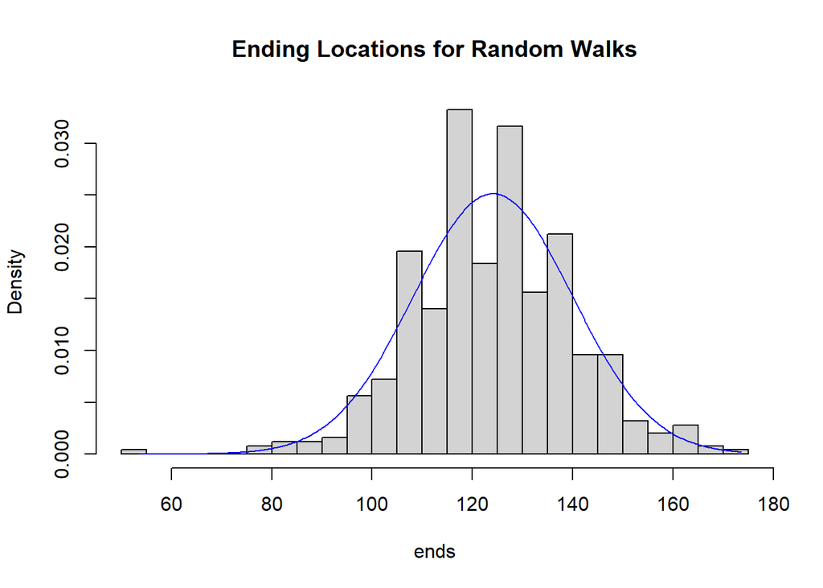

```r
sim_num <- 500
step_count <- 250
velocity <- 0.5
ends = c()
for (j in 1:sim_num){
  path = c(0)
  for (k in 2:step_count){
    path[k] = path[k - 1] + sample(options + velocity, 1)
  }
  ends[j] <- path[step_count]
}
hist(ends, main="Ending Locations for Random Walks", freq=FALSE, breaks = 20)
x <- seq(min(ends), max(ends), length=sim_num)
y <- dnorm(x, mean=mean(ends), sd=sd(ends))
lines(x, y, col="blue")
```

```r
mean(ends)
```

```
## [1] 124.08
```

```r
sd(ends)
```

```
## [1] 15.88005
```